# Tarea 9. Observadores de Estado

Marco Antonio Esquivel Basaldua

```python
import numpy as np
import control as ctr
import scipy as sp
import matplotlib.pyplot as plt
%matplotlib inline
from scipy.integrate import odeint
```

# Control por realimentación del estado

Se considera el sistema cuya función de transferencia es $$ \begin{split} \frac{Y(s)}{U(s)}&=\frac{2}{(s+0.5)(s+0.1)(s+5)}\\ &=\frac{2}{s^3+5.6s^2+3.05s+0.25} \end{split} $$ Y cuya respresentación en variables de estado es $$ \dot{\textbf{x}} = A\textbf{x} + Bu(t)\\ y = C\textbf{x} $$ Donde $$A = \left[\begin{matrix}0 & 1 & 0\\0 & 0 & 1\\-0.25 & -3.05 & -5.6 \end{matrix}\right]$$ $$B=\left[\begin{matrix}0\\0\\1 \end{matrix}\right]$$ $$C=\left[\begin{matrix}2 & 0 & 0 \end{matrix}\right]$$

```python
# Funcion de transferencia del sistema
num = np.array([0., 0., 0., 2.])
den = np.array([1., 5.6, 3.05, 0.25])

sys_tf = ctr.TransferFunction(num,den)

# Sistema en variables de estado
A = np.array([[0.,1.,0.],[0.,0.,1.],[-0.25,-3.05,-5.6]])
B = np.array([[0.],[0.],[1.]])
C = np.array([[2.,0.,0.]])
D = np.array([[0.]])

sys_ss = ctr.StateSpace(A, B, C, D)
```

# Estabilidad del sistema

Para que el sistema pueda ser estabilizable mediante la realimentación por variables de estado, el sistema debe ser controlable y observable. La matriz de controlabilidad del sistema es $$ \mathcal{C}= \left[\begin{matrix} 0 & 0 & 1\\ 0 & 1 & -5.6\\ 1 & -5.6 & 28.31 \end{matrix}\right] $$

La matriz de observabiliad del sistema es $$ \mathcal{O}= \left[\begin{matrix} 2 & 0 & 0\\ 0 & 2 & 0\\ 0 & 0 & 2 \end{matrix}\right] $$

Ya que el determinante de ambas matrices es diferente de cero, se dice que el sistema es controlable y observable.

```python
C_ = ctr.ctrb(A,B)
print('Matriz de controlabilidad')
print(C_)
print('det(C)= ', np.linalg.det(C_))

O_ = ctr.obsv(A,C)
print('Matriz de Observabilidad')
print(O_)
print('det(O)= ', np.linalg.det(O_))
```

```
Matriz de controlabilidad
[[ 0.    0.    1.  ]
 [ 0.    1.   -5.6 ]
 [ 1.   -5.6  28.31]]
det(C)=  -1.0
Matriz de Observabilidad
[[2. 0. 0.]
 [0. 2. 0.]
 [0. 0. 2.]]
det(O)=  7.999999999999998
```

## Observador en lazo abierto con $u(t)=0$

Simulación en variales de estado considerando $u(t)=0$ y $$ \textbf{x}(0)=\left[\begin{matrix}x_1(0)\\x_2(0)\\x_3(0)\end{matrix}\right] =\left[\begin{matrix}1\\0.5\\-1\end{matrix}\right] $$

El observador en lazo abierto genera un vector de estados estimados a partir de una estimación inicial del estado y de la siguiente expresión. $$ \dot{\hat{\textbf{x}}}=A\hat{\textbf{x}} + Bu $$

Esta duplicación resulta en un diagrama de bloques como la que se muestra a continuación.

[figure not shown]

### Valores reales del vector $\textbf{x}$

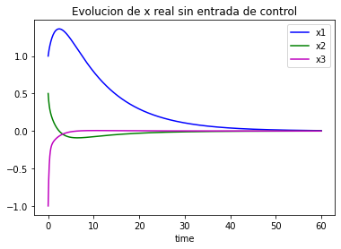

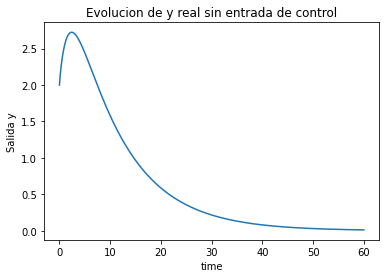

```python
u = 0
b = np.array([B[0,0],B[1,0] ,B[2,0]])
def x_dot(xi,t):
    return A.dot(xi) + b*u

x_0 = np.array([1.,0.5,-1.])
t = np.linspace(0,60,1001)

x = odeint(x_dot,x_0,t)

y = 2*x[:,0]

plt.plot(t,x[:,0], 'b', label='x1')
plt.plot(t,x[:,1], 'g', label='x2')
plt.plot(t,x[:,2], 'm', label='x3')
plt.title('Evolucion de x real sin entrada de control')
plt.legend(loc='best')
plt.xlabel('time')
plt.show()

plt.plot(t,y)
plt.title('Evolucion de y real sin entrada de control')
plt.xlabel('time')
plt.ylabel('Salida y')
plt.show()
```

### Valores del estimador, $\hat{\textbf{x}}$

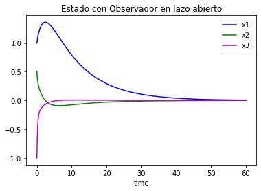

```python
def x_hat_dot(xi,t):
    return A.dot(xi) + b*u

x_0 = np.array([1.,0.5,-1.])
t = np.linspace(0,60,1001)

x_hat = odeint(x_hat_dot,x_0,t)

plt.plot(t,x_hat[:,0], 'b', label='x1')
plt.plot(t,x_hat[:,1], 'g', label='x2')
plt.plot(t,x_hat[:,2], 'm', label='x3')
plt.title('Estado con Observador en lazo abierto')
plt.legend(loc='best')
plt.xlabel('time')
plt.show()
```

### Error del estimador

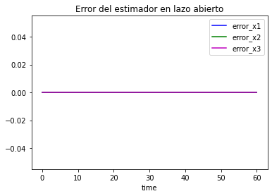

```python
x_tilde = np.array(len(t))

x_tilde = x - x_hat

plt.plot(t,x_tilde[:,0], 'b', label='error_x1')
plt.plot(t,x_tilde[:,1], 'g', label='error_x2')
plt.plot(t,x_tilde[:,2], 'm', label='error_x3')
plt.title('Error del estimador en lazo abierto')
plt.legend(loc='best')
plt.xlabel('time')
plt.show()
```

### Valores del estimador, $\hat{\textbf{x}}$. Condición inicial con ligeras perturbaciones

```
x_0=  [ 1.6   0.8  -0.87]
```

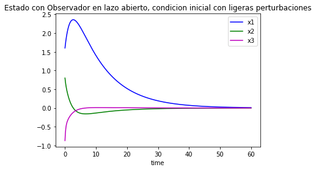

```python
def x_hat_dot(xi,t):
    return A.dot(xi) + b*u

x_0 = np.array([1.6,0.8,-0.87])
print('x_0= ',x_0)
t = np.linspace(0,60,1001)

x_hat = odeint(x_hat_dot,x_0,t)

plt.plot(t,x_hat[:,0], 'b', label='x1')
plt.plot(t,x_hat[:,1], 'g', label='x2')
plt.plot(t,x_hat[:,2], 'm', label='x3')
plt.title('Estado con Observador en lazo abierto, condicion inicial con ligeras perturbaciones')
plt.legend(loc='best')
plt.xlabel('time')
plt.show()
```

### Error del estimador

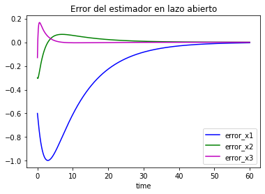

```python
x_tilde = x - x_hat

plt.plot(t,x_tilde[:,0], 'b', label='error_x1')
plt.plot(t,x_tilde[:,1], 'g', label='error_x2')
plt.plot(t,x_tilde[:,2], 'm', label='error_x3')
plt.title('Error del estimador en lazo abierto')
plt.legend(loc='best')
plt.xlabel('time')
plt.show()
```

## Observador en lazo cerrado

Se usa el valor $y(t)$ para mejorar el diseño del observador introduciendo una corrección proporcional al error de estimación de la salida. El sistema resultante se muestra en el siguiente diagrama de bloques.

[figure not shown]

El valor estimado del vector de estados es entonces $$ \dot{\hat{\textbf{x}}}(t) = A\hat{\textbf{x}}(t) + Bu(t) + L[y(t) - C\hat{\textbf{x}}(t)] $$

### Cálculo del vector $L$ con la fórmula de Ackerman

```python
At = np.array([[0.,0.,-0.25],[1.,0.,-3.05],[0.,1.,-5.6]])
Ct = np.array([[2.],[0.],[0.]])

L = ctr.acker(At,Ct,[-0.25, -0.5, -25.]).T
print(L)
#L = np.array([L[0,0], L[1,0], L[2,0]])
```

```
[[ 10.075  ]
 [-48.5075 ]
 [242.35075]]
```

### Implementación del Obsservador en lazo cerrado

```
x_0=  [[ 1. ]
 [ 0.5]
 [-1. ]]
x_0_hat=  [[ 1.6 ]
 [ 0.8 ]
 [-0.87]]
```

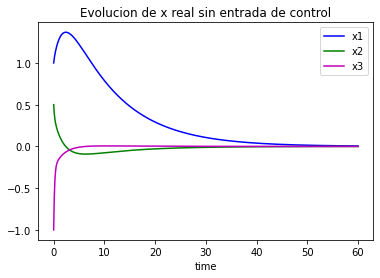

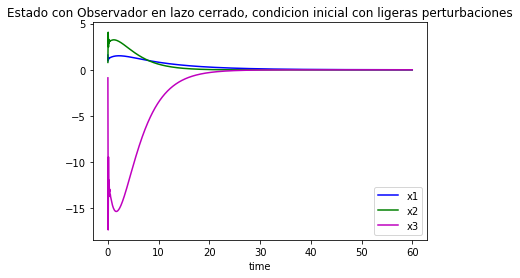

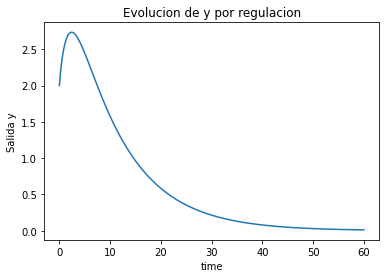

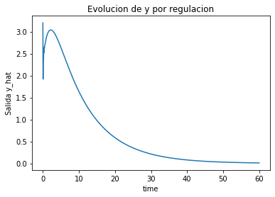

```python
u = 0
def x_hat_byEuler(x0,x0_hat,t):
    x = np.zeros((3, len(t)))
    y = np.zeros(len(t))

    x_hat = np.zeros((3, len(t)))
    y_hat = np.zeros(len(t))

    h = t[1] - t[0]

    xn = x0
    yn = 2*xn[0]
    x[0,0] = xn[0]
    x[1,0] = xn[1]
    x[2,0] = xn[2]
    y[0] = yn

    xn_hat = x0_hat
    yn_hat = 2*xn_hat[0]
    x_hat[0,0] = xn_hat[0]
    x_hat[1,0] = xn_hat[1]
    x_hat[2,0] = xn_hat[2]
    y_hat[0] = yn_hat

    for n in range(1, len(t)):
        ## Vector de estados real
        xn1 = xn + h*(A.dot(xn) + B*u)
        x[0,n] = xn1[0]
        x[1,n] = xn1[1]
        x[2,n] = xn1[2]

        yn = 2*xn1[0]
        y[n] = yn

        xn = xn1

        # Vector de estados estimado
        xn1_hat = xn_hat + h*(A.dot(xn_hat) + B*u + L*(yn - yn_hat))
        x_hat[0,n] = xn1_hat[0]
        x_hat[1,n] = xn1_hat[1]
        x_hat[2,n] = xn1_hat[2]

        yn_hat = 2*xn1_hat[0]
        y_hat[n] = yn_hat

        xn_hat = xn1_hat

    return x, y, x_hat, y_hat


x_0 = np.array([[1.],[0.5],[-1.]])
x_0_hat = np.array([[1.6],[0.8],[-.87]])
print('x_0= ',x_0)
print('x_0_hat= ',x_0_hat)
t = np.linspace(0,60,1001)

x, y, x_hat, y_hat = x_hat_byEuler(x_0,x_0_hat,t)

plt.plot(t,x[0,:], 'b', label='x1')
plt.plot(t,x[1,:], 'g', label='x2')
plt.plot(t,x[2,:], 'm', label='x3')
plt.title('Evolucion de x real sin entrada de control')
plt.legend(loc='best')
plt.xlabel('time')
plt.show()

plt.plot(t,x_hat[0,:], 'b', label='x1')
plt.plot(t,x_hat[1,:], 'g', label='x2')
plt.plot(t,x_hat[2,:], 'm', label='x3')
plt.title('Estado con Observador en lazo cerrado, condicion inicial con ligeras perturbaciones')
plt.legend(loc='best')
plt.xlabel('time')
plt.show()

#salidas
plt.plot(t,y)
plt.title('Evolucion de y por regulacion')
plt.xlabel('time')
plt.ylabel('Salida y')
plt.show()

plt.plot(t,y_hat)
plt.title('Evolucion de y por regulacion')
plt.xlabel('time')
plt.ylabel('Salida y_hat')
plt.show()
```

### Error del estimador

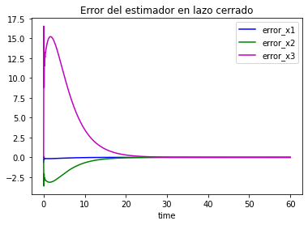

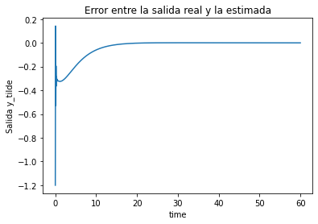

```python
x_tilde = x - x_hat

y_tilde = y - y_hat

plt.plot(t,x_tilde[0,:], 'b', label='error_x1')
plt.plot(t,x_tilde[1,:], 'g', label='error_x2')
plt.plot(t,x_tilde[2,:], 'm', label='error_x3')
plt.title('Error del estimador en lazo cerrado')
plt.legend(loc='best')
plt.xlabel('time')
plt.show()

plt.plot(t,y_tilde)
plt.title('Error entre la salida real y la estimada')
plt.xlabel('time')
plt.ylabel('Salida y_tilde')
plt.show()
```

## El problema de regulación

Se desea resolver el problema de regualción con las especificaciones dadas en la tarea anterior en la que se solicitaba un factor de amortiguamiento de 0.5 y un tiempo se asentamiento de 2 segundos. Tal como se especificó, los polos del sistema deseado son $$s_1=-2+3.4641i$$ $$s_2=-2-3.4641i$$ $$s_3=-10$$

Se realizará una comparativa entre los resultados obtenidos ante una realimentación del estado real y ante una realimetación del estado estimado para una entrada tipo escalón unitario.

### Vector de ganancias del controlador

Inicialmente se calcula el vector de ganancias usando la función de ackerman para los polos deseados

```python
K = ctr.acker(A,B,[complex(-2,3.4641),complex(-2,-3.4641),-10.])
print(K)
```

```
[[159.7498881   52.94998881   8.4       ]]
```

### Vector de ganancias del observador

```python
speed = 5.
L = ctr.acker(At,Ct,[speed*complex(-2,3.4641), speed*complex(-2,-3.4641), speed*(-10.)]).T
print(L)
```

```
[[  32.2       ]
 [ 518.15486013]
 [6999.99078955]]
```

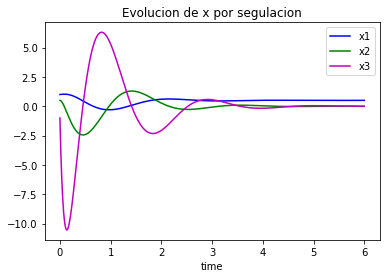

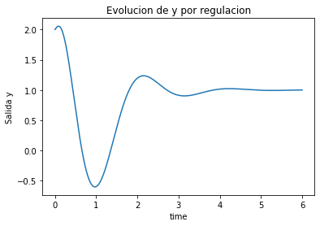

```
Maximo sibreimpulso
0.23604575834555797
```

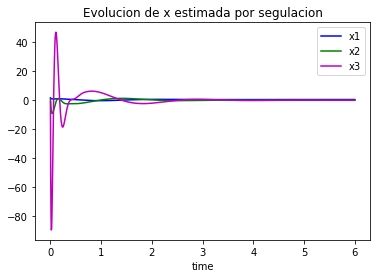

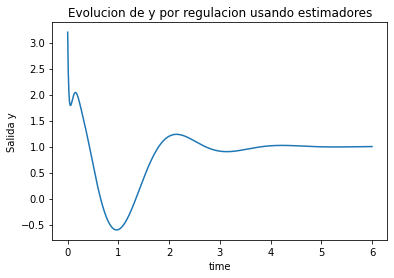

```
Maximo sibreimpulso
0.23605356316050652
```

```python
def x_byEuler(x0, x0_hat, r, t):
    x = np.zeros((3, len(t)))
    y = np.zeros(len(t))

    x_hat = np.zeros((3, len(t)))
    y_hat = np.zeros(len(t))

    h = t[1] - t[0]

    xn = x0
    yn = 2*xn[0]
    x[0,0] = xn[0]
    x[1,0] = xn[1]
    x[2,0] = xn[2]
    y[0] = yn

    xn_hat = x0_hat
    yn_hat = 2*xn_hat[0]
    x_hat[0,0] = xn_hat[0]
    x_hat[1,0] = xn_hat[1]
    x_hat[2,0] = xn_hat[2]
    y_hat[0] = yn_hat

    chi_n = 0.

    KI = 90.
    for n in range(1, len(t)):
        # Vector de estados real
        u = chi_n*KI - K.dot(xn)

        xn1 = xn + h*(A.dot(xn) + B*u)
        x[0,n] = xn1[0]
        x[1,n] = xn1[1]
        x[2,n] = xn1[2]

        yn = 2*xn1[0]
        y[n] = yn

        xn = xn1

        # Vector de estados estimado
        u_hat = chi_n*KI - K.dot(xn_hat)

        xn1_hat = xn_hat + h*(A.dot(xn_hat) + B*u_hat + L*(yn - yn_hat))
        x_hat[0,n] = xn1_hat[0]
        x_hat[1,n] = xn1_hat[1]
        x_hat[2,n] = xn1_hat[2]

        yn_hat = 2*xn1_hat[0]
        y_hat[n] = yn_hat

        xn_hat = xn1_hat

        chi_n = chi_n + h*(r - yn)

    return x, y, x_hat, y_hat




x_0 = np.array([[1.],[0.5],[-1.]])
x_0_hat = np.array([[1.6],[0.8],[-0.87]])
t = np.linspace(0,6,1001)

x,y,x_hat,y_hat = x_byEuler(x_0, x_0_hat, 1, t)

plt.plot(t,x[0,:], 'b', label='x1')
plt.plot(t,x[1,:], 'g', label='x2')
plt.plot(t,x[2,:], 'm', label='x3')
plt.title('Evolucion de x por segulacion')
plt.legend(loc='best')
plt.xlabel('time')
plt.show()

plt.plot(t,y)
plt.title('Evolucion de y por regulacion')
plt.xlabel('time')
plt.ylabel('Salida y')
plt.show()

print('Maximo sibreimpulso')
print(abs(1-max(y[300:])))


plt.plot(t,x_hat[0,:], 'b', label='x1')
plt.plot(t,x_hat[1,:], 'g', label='x2')
plt.plot(t,x_hat[2,:], 'm', label='x3')
plt.title('Evolucion de x estimada por segulacion')
plt.legend(loc='best')
plt.xlabel('time')
plt.show()

plt.plot(t,y_hat)
plt.title('Evolucion de y por regulacion usando estimadores')
plt.xlabel('time')
plt.ylabel('Salida y')
plt.show()

print('Maximo sibreimpulso')
print(abs(1-max(y_hat[300:])))
```

### Errores

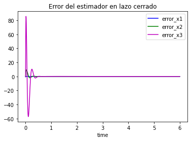

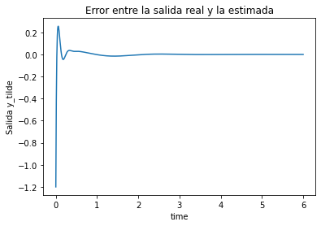

```python
x_tilde = x - x_hat

y_tilde = y - y_hat

plt.plot(t,x_tilde[0,:], 'b', label='error_x1')
plt.plot(t,x_tilde[1,:], 'g', label='error_x2')
plt.plot(t,x_tilde[2,:], 'm', label='error_x3')
plt.title('Error del estimador en lazo cerrado')
plt.legend(loc='best')
plt.xlabel('time')
plt.show()

plt.plot(t,y_tilde)
plt.title('Error entre la salida real y la estimada')
plt.xlabel('time')
plt.ylabel('Salida y_tilde')
plt.show()
```

## Esquema Controlador-Observador

Se desea aplicar el esquema controlador-observador de acuerdo al siguiente diagrama, para una entrada de referencia tipo escalon unitario.

[figure not shown]

Los valores en las ganancias del controlador se conservarán de acuerdo a las ya establecidas mientras que se aplicará una comparativa entre un observador lento y uno rápido.

```python
A_BK = A - B.dot(K)
N = -1./(C.dot(np.linalg.inv(A_BK)).dot(B))

def con_obs(x0, x0_hat, r, t):
    x = np.zeros((3, len(t)))
    y = np.zeros(len(t))

    x_hat = np.zeros((3, len(t)))
    y_hat = np.zeros(len(t))

    h = t[1] - t[0]

    xn = x0
    yn = 2*xn[0]
    x[0,0] = xn[0]
    x[1,0] = xn[1]
    x[2,0] = xn[2]
    y[0] = yn

    xn_hat = x0_hat
    yn_hat = 2*xn_hat[0]
    x_hat[0,0] = xn_hat[0]
    x_hat[1,0] = xn_hat[1]
    x_hat[2,0] = xn_hat[2]
    y_hat[0] = yn_hat

    for n in range(1, len(t)):
        u = r*N - K.dot(xn_hat)

        # Vector de estados real
        xn1 = xn + h*(A.dot(xn) + B*u)
        x[0,n] = xn1[0]
        x[1,n] = xn1[1]
        x[2,n] = xn1[2]

        yn = 2*xn1[0]
        y[n] = yn

        xn = xn1

        # Vector de estados estimado
        xn1_hat = xn_hat + h*(A.dot(xn_hat) + B*u + L*(yn - yn_hat))
        x_hat[0,n] = xn1_hat[0]
        x_hat[1,n] = xn1_hat[1]
        x_hat[2,n] = xn1_hat[2]

        yn_hat = 2*xn1_hat[0]
        y_hat[n] = yn_hat

        xn_hat = xn1_hat

    return x, y, x_hat, y_hat
```

### Observador rápido

Se genera un vector de ganancias para el observador que corresponde a 5 veces más rápido que el controlador

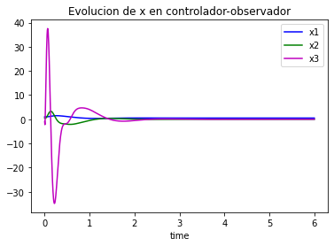

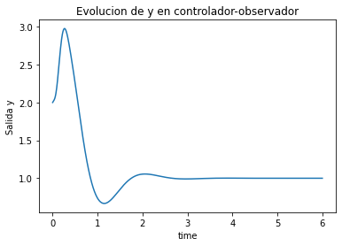

```
Maximo sibreimpulso
0.05601477659847176
```

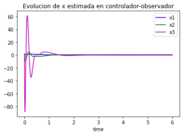

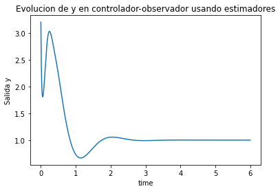

```
Maximo sibreimpulso
0.0560087599741832
```

```python
speed = 5.
L = ctr.acker(At,Ct,[speed*complex(-2,3.4641), speed*complex(-2,-3.4641), speed*(-10.)]).T

x_0 = np.array([[1.],[0.5],[-1.]])
x_0_hat = np.array([[1.6],[0.8],[-0.87]])
t = np.linspace(0,6,1001)

x,y,x_hat,y_hat = con_obs(x_0, x_0_hat, 1., t)

plt.plot(t,x[0,:], 'b', label='x1')
plt.plot(t,x[1,:], 'g', label='x2')
plt.plot(t,x[2,:], 'm', label='x3')
plt.title('Evolucion de x en controlador-observador')
plt.legend(loc='best')
plt.xlabel('time')
plt.show()

plt.plot(t,y)
plt.title('Evolucion de y en controlador-observador')
plt.xlabel('time')
plt.ylabel('Salida y')
plt.show()

print('Maximo sibreimpulso')
print(abs(1-max(y[300:])))


plt.plot(t,x_hat[0,:], 'b', label='x1')
plt.plot(t,x_hat[1,:], 'g', label='x2')
plt.plot(t,x_hat[2,:], 'm', label='x3')
plt.title('Evolucion de x estimada en controlador-observador')
plt.legend(loc='best')
plt.xlabel('time')
plt.show()

plt.plot(t,y_hat)
plt.title('Evolucion de y en controlador-observador usando estimadores')
plt.xlabel('time')
plt.ylabel('Salida y')
plt.show()

print('Maximo sibreimpulso')
print(abs(1-max(y_hat[300:])))
```

### Errores

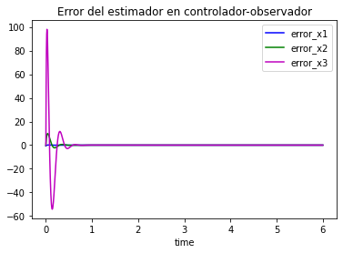

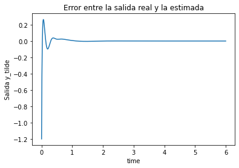

```python
x_tilde = x - x_hat

y_tilde = y - y_hat

plt.plot(t,x_tilde[0,:], 'b', label='error_x1')
plt.plot(t,x_tilde[1,:], 'g', label='error_x2')
plt.plot(t,x_tilde[2,:], 'm', label='error_x3')
plt.title('Error del estimador en controlador-observador')
plt.legend(loc='best')
plt.xlabel('time')
plt.show()

plt.plot(t,y_tilde)
plt.title('Error entre la salida real y la estimada')
plt.xlabel('time')
plt.ylabel('Salida y_tilde')
plt.show()
```

### Observador lento

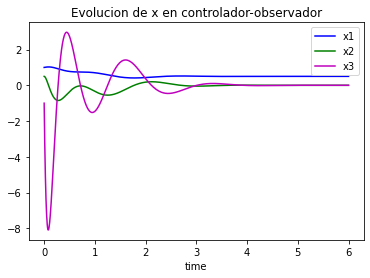

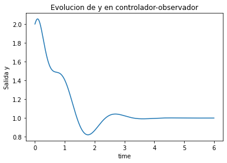

```
Maximo sibreimpulso
0.04273306302658364
```

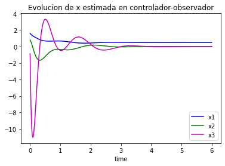

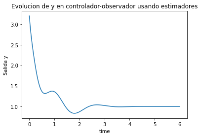

```
Maximo sibreimpulso
0.04101814373471169
```

```python
speed = 1.
L = ctr.acker(At,Ct,[speed*complex(-2,3.4641), speed*complex(-2,-3.4641), speed*(-10.)]).T

x_0 = np.array([[1.],[0.5],[-1.]])
x_0_hat = np.array([[1.6],[0.8],[-0.87]])
t = np.linspace(0,6,1001)

x,y,x_hat,y_hat = con_obs(x_0, x_0_hat, 1., t)

plt.plot(t,x[0,:], 'b', label='x1')
plt.plot(t,x[1,:], 'g', label='x2')
plt.plot(t,x[2,:], 'm', label='x3')
plt.title('Evolucion de x en controlador-observador')
plt.legend(loc='best')
plt.xlabel('time')
plt.show()

plt.plot(t,y)
plt.title('Evolucion de y en controlador-observador')
plt.xlabel('time')
plt.ylabel('Salida y')
plt.show()

print('Maximo sibreimpulso')
print(abs(1-max(y[300:])))


plt.plot(t,x_hat[0,:], 'b', label='x1')
plt.plot(t,x_hat[1,:], 'g', label='x2')
plt.plot(t,x_hat[2,:], 'm', label='x3')
plt.title('Evolucion de x estimada en controlador-observador')
plt.legend(loc='best')
plt.xlabel('time')
plt.show()

plt.plot(t,y_hat)
plt.title('Evolucion de y en controlador-observador usando estimadores')
plt.xlabel('time')
plt.ylabel('Salida y')
plt.show()

print('Maximo sibreimpulso')
print(abs(1-max(y_hat[300:])))
```

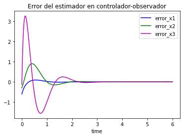

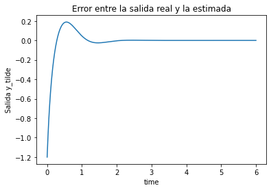

```python
x_tilde = x - x_hat

y_tilde = y - y_hat

plt.plot(t,x_tilde[0,:], 'b', label='error_x1')
plt.plot(t,x_tilde[1,:], 'g', label='error_x2')
plt.plot(t,x_tilde[2,:], 'm', label='error_x3')
plt.title('Error del estimador en controlador-observador')
plt.legend(loc='best')
plt.xlabel('time')
plt.show()

plt.plot(t,y_tilde)
plt.title('Error entre la salida real y la estimada')
plt.xlabel('time')
plt.ylabel('Salida y_tilde')
plt.show()
```